# Learning CHARME models with DNN

José Gregorio Gómez-García, Jalal Fadili, Christophe Chesneau

7/2/2022

## Summary

- This is an [R Markdown](http://rmarkdown.rstudio.com). You can execute the entire code by clicking “Knit” or taping *Ctrl+Shift+K*. The results will appear beneath each chuck.
- You can also execute each chuck by clicking the *Run* button within the chunk or by placing your cursor inside it and pressing *Ctrl+Shift+Enter*.
- In this R Markdown we present the codes in order to reproduce the experiments of the article: [Learning CHARME models with neural networks](https://arxiv.org/abs/2002.03237).

### Requeriments

First, install the tensorflow R package from GitHub as follows:

```r
#install.packages("tensorflow")
```

Then, use the [`install_tensorflow()`](https://tensorflow.rstudio.com/reference/tensorflow/install_tensorflow/) function to install TensorFlow. Note that on Windows you need a working installation of [Anaconda](https://www.anaconda.com/products/distribution).

```r
library(tensorflow)
install_tensorflow()
```

```
## Installing: tensorflow-deps==2.6
```

```
## Installing: tensorflow-macos==2.6.0
```

```
## Installing: tensorflow-metal==0.2.0
```

You can confirm that the installation succeeded with:

```r
library(tensorflow)
tf$constant("Hellow Tensorflow")
```

```
## Loaded Tensorflow version 2.6.0
```

```
## tf.Tensor(b'Hellow Tensorflow', shape=(), dtype=string)
```

Before running the quickstart you need to have Keras and sigmoid installed.

```r
library(keras)
library(sigmoid)
```

You need also to load the functions from *charme_tools.R*.

```r
source("charme_tools.R")
```

*charme_tools.R* contains the following functions:

- `sample.model.architecture`, which randomly generates the weights of the specified dense architecture.  
  Here, units.vector = c($N_0$, $N_1$, …, $N_L$), where $N_0=$dimension_input, $N_L=$dimension_output and delta is such that the rang of the values of W are in [-delta, delta].

Example:

```r
Architecture <- sample.model.architecture(units.vector=c(5,8,10,10,1), delta=0.3)
Architecture[[2]]
```

```
## [1] 1.471423
```

- `model_function`, which is the neural network parametrized by a list of weights and biases. For example, this list of weights and biases can be generated with the `sample.model.architecture` function.

Here, the parameter `weights_biases` is a list, where for each `l`, `weights_biases[[l]]` is the extended matrix $(W^{(l)}, b^{(l)})$ (see [article](https://arxiv.org/abs/2002.03237)) and `x0` is the input (no extended).

Example:

```r
x0 <- c(1,-1,2,9,3)
model_function(weights_biases=Architecture[[1]], activation.function=relu, x0)
```

```
##           [,1]
## [1,] 0.2348096
```

- `Switching`, which generates `n` values between `1` and `length(prob)` with probabilities `prob` (the vector of probability weights). Note that `sum(prob)`$=\sum_{i=1}^p \pi_i=1$ must be equal `1`.

Example:

```r
S <- Switching(20, c(0.25,0.1,0.25, 0.4))
S
```

```
##  [1] 3 2 3 4 3 4 4 2 4 2 1 3 4 3 1 3 3 1 4 4
```

- `Index_Switching`, which gives the indexes `i` such that *Observations[i]=x*.

Example:

```r
Index_Switching(S, x=1)
```

```
## [1] 11 15 18
```

- `T_KG`, which transforms a list in Keras format to `sample.model.architecture` format.

For the Multivariate Normality Tests (MVN) of [Korkmaz et al, (2014)](https://cran.r-project.org/web/packages/MVN/index.html) you need a version of R greater than 3.5. In this case, we can install the package MVN:

```r
#install.packages("MVN")
library(MVN)
```

Otherwise, don’t worry, we have included the necessary setClass and functions in *charme_tools_MVN.R*, taken from the [old versions](https://cran.r-project.org/src/contrib/Archive/MVN/) in the CRAN).

If *MVN* package is not available, load the `charme_tools_MVN.R` file :

```r
#source("charme_tools_MVN.R")
```

## 1. Training NNs with a NN-based CHARME data.

### 1.1. Generation of the data

#### 1.1.1. Generation of the true parameter $\theta^{0}$ of the model:

```r
NN1 <- sample.model.architecture(c(30,50,60,40,20,1), 0.1)
NN2 <- sample.model.architecture(c(30,20,5,1), 0.09)
NN3 <- sample.model.architecture(c(30,25,30,1), 0.05)
# 10295 parameters
```

Now, we change the last biases in order to obtain abrupt changes

```r
NN1[[1]][[length(NN1[[1]])]][1,21] <- 1
NN2[[1]][[length(NN2[[1]])]][1,6] <- 0
NN3[[1]][[length(NN3[[1]])]][1,31] <- -1
```

We set the probabilities $(\pi_1, \pi_2, \pi_3)=(0.1, 0.4, 0.5)$. Notice that $c=\sum_{k=1}^{3}\pi_k A_k$ must be less than 1 in order to obtain stationarity in the model. In fact,

```r
prob <- c(0.1, 0.4, 0.5)
c <- prob%*%c(NN1[[2]], NN2[[2]], NN3[[2]])
c
```

```
##           [,1]
## [1,] 0.8711092
```

Once we have verified that $c <1$, we forget the $A_k=$`NNk[[2]]` and we rename the parameters as follows:

```r
NN1 <- NN1[[1]] #theta_1^0
NN2 <- NN2[[1]] #theta_2^0
NN3 <- NN3[[1]] #theta_3^0
```

#### 1.1.2. Generation of the time series

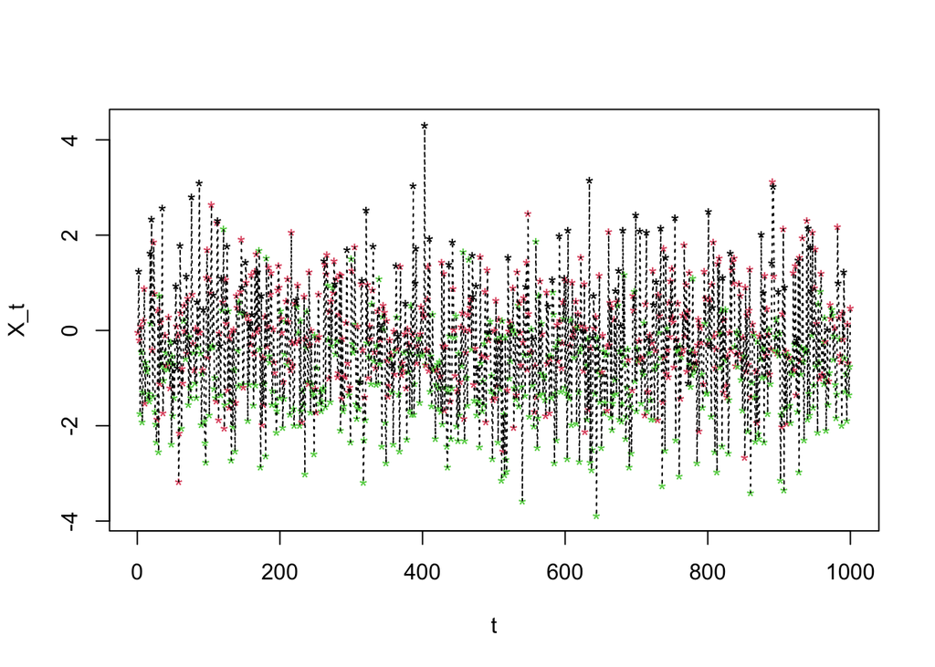

```r
n <- 100000
X <- c(NA)
p <- ncol(NN1[[1]])-1
e <- rnorm(n+100)
X[1:p] <- e[1:p]
S <- Switching(n+100,prob)
for (t in (p+1):(n+100)){
  X[t] <- (rep(S[t],length(prob)) == 1:length(prob)) %*% c(model_function(NN1, relu, X[(t-1):(t-p)]),
                                                           model_function(NN2, relu, X[(t-1):(t-p)]),
                                                           model_function(NN3, relu, X[(t-1):(t-p)])) + e[t]
}
St <- S[100:length(S)]
Xt <- X[100:length(S)]
plot(Xt[1:1000], col=St, pch='*', ylab = 'X_t', xlab = 't' )
lines(Xt[1:1000],lty=3)
```

### 1.2. Estimation or learning

We build a matrix $D=[R_t, X_t, (X_{t-1}, \ldots, X_{t-p})] \in \mathbb{M}_{n\times p+2}(\mathbb{R})$ that we separate according to the state of $R_t$:

```r
D <- matrix(NA, ncol = p+2, nrow = n-p)
for (t in 1:(n-p)){
  D[t,] <- c(St[t+p], Xt[(t+p):t])
}
D1 <- D[Index_Switching(D[,1],1),]
D2 <- D[Index_Switching(D[,1],2),]
D3 <- D[Index_Switching(D[,1],3),]
```

For each case, we set the NN model and then estimate the weights and biases via the SGD algorithm.

#### For the regime or state 1:

```r
model1 <- keras_model_sequential()

model1 %>%
  layer_dense(units = 50, input_shape = 30) %>%
  #layer_dropout(rate=0.25)%>%
  layer_activation(activation = 'relu') %>%
  layer_dense(units = 60) %>%
  layer_activation(activation = 'relu') %>%
  layer_dense(units = 40) %>%
  layer_activation(activation = 'relu') %>%
  layer_dense(units = 20) %>%
  layer_activation(activation = 'relu') %>%
  layer_dense(units = 1)

model1 %>% compile(
  loss = 'mean_squared_error',
  optimizer = optimizer_sgd(),
  metrics = 'mae'
)

X.train1 <- D1[, 3:ncol(D1)]
Y.train1 <- D1[,2]

model1 %>% fit(X.train1, Y.train1, epochs = 20)

cat("\014") # is the code to send CTRL+L to the console and therefore will clear the screen.
```

#### For the regime or state 2:

```r
model2 <- keras_model_sequential()

model2 %>%
  layer_dense(units = 20, input_shape = 30) %>%
  layer_activation(activation = 'relu') %>%
  layer_dense(units = 5) %>%
  layer_activation(activation = 'relu') %>%
  layer_dense(units = 1)

model2 %>% compile(
  loss = 'mean_squared_error',
  optimizer = optimizer_sgd(), #optimizer_sgd(learning_rate = 0.001, decay=0.5),
  metrics = 'mae'
)

X.train2 <- D2[, 3:ncol(D1)]
Y.train2 <- D2[,2]

model2 %>% fit(X.train2, Y.train2, epochs = 20)

cat("\014") # is the code to send CTRL+L to the console and therefore will clear the screen.
```

#### For the regime or state 3:

```r
model3 <- keras_model_sequential()

model3 %>%
  layer_dense(units = 25, input_shape = 30) %>%
  layer_activation(activation = 'relu') %>%
  layer_dense(units = 30) %>%
  layer_activation(activation = 'relu') %>%
  layer_dense(units = 1)

model3 %>% compile(
  loss = 'mean_squared_error',
  optimizer = optimizer_sgd(), #optimizer_sgd(learning_rate = 0.001, decay=0.5),
  metrics = 'mae'
)

X.train3 <- D3[, 3:ncol(D1)]
Y.train3 <- D3[,2]

model3 %>% fit(X.train3, Y.train3, epochs = 20)

cat("\014") # is the code to send CTRL+L to the console and therefore will clear the screen.
```

### 1.3. Study of the resilduals.

To do this, we first transform the list of weights and biases calculated in Keras format to our format in order to give the estimated autogression functions

```r
cat("\014") # is the code to send CTRL+L to the console and therefore will clear the screen.
```

```r
theta1_t <- T_KG(get_weights(model1))
```

```
## [1] 10
```

```r
theta2_t <- T_KG(get_weights(model2))
```

```
## [1] 6
```

```r
theta3_t <- T_KG(get_weights(model3))
```

```
## [1] 6
```

and calculate the estimated residuals: $\hat{\epsilon}_t=X_t^{(k)}-f_k(X_{t-1}, \ldots, X_{t-p}; \hat{\theta_k})$ according to the case.

```r
hat.e1 <- Y.train1 - apply(X.train1, 1, function(x){model_function(theta1_t, relu, x)})
hat.e2 <- Y.train2 - apply(X.train2, 1, function(x){model_function(theta2_t, relu, x)})
hat.e3 <- Y.train3 - apply(X.train3, 1, function(x){model_function(theta3_t, relu, x)})
hat.e <- c(hat.e1, hat.e2, hat.e3)
```

The following figures shows the Gaussian behavior of the errors obtained

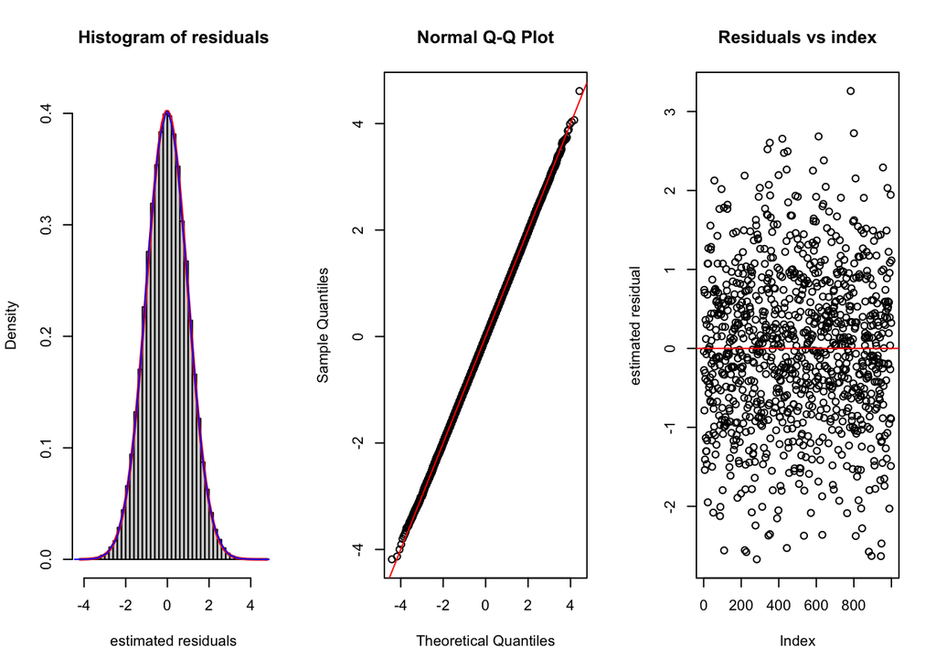

```r
par(mfrow=c(1,3))
hist(hat.e, prob=TRUE, breaks=40, ylim=c(0,0.42), main = 'Histogram of residuals', xlab = 'estimated residuals')
curve(dnorm(x, mean(hat.e), sd(hat.e)), add=TRUE, col="red", lwd=2)
lines(density(hat.e), col='blue')
qqnorm(hat.e)
abline(a=0, b=1, col='red')
s <- sample(1:length(hat.e), 1000)
plot(hat.e[s], ylab = 'estimated residual', main = "Residuals vs index"  )
abline(a=0, b=0, col='red')
```

## 2. Training NNs with a mixing CHARME data.

### 2.1. Generation of the data

We consider first the following functions:

```r
f_ar <- function(ar_parameters, input){
  return(ar_parameters[-1]%*%input + ar_parameters[1])
}
f_arch <- function(arch_parameters, input){
  return(sqrt(arch_parameters[-1]%*%input^2 +  arch_parameters[1]))
}
```

So, we generate the data:

```r
n <- 100000
X2 <- c(NA)
p <- 5
X2[1:p] <- rnorm(5)
e2 <- rnorm(n+100)
prob2 <- c(0.15, 0.35, 0.5)
S2 <- Switching(n+100,prob2)
parameter1 <- c(0.1, 0.05, 0.2, 0.15, 0.03, 0.01)
parameter2 <- c(-3, 0.2, 0.1, 0.25, 0.2, 0.05)
c_e2 <- prob2%*%c(1, sum(parameter1[-1]), sum(parameter2[-1]))
c_e2
```

```
##       [,1]
## [1,] 0.704
```

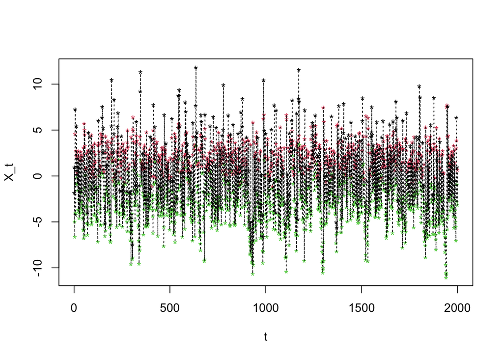

```r
for (t in (p+1):(n+100)){
  X2[t] <- (rep(S2[t],length(prob2)) == 1:length(prob2)) %*% c(3 + X2[t-1],
                                                               f_arch(parameter1, X2[(t-1):(t-p)]),
                                                               f_ar(parameter2, X2[(t-1):(t-p)])) + e2[t]
}
St2 <- S2[100:length(S2)]
Xt2 <- X2[100:length(S2)]
plot(Xt2[1:2000], col=St2, pch='*', ylab = 'X_t', xlab = 't' )
lines(Xt2[1:2000],lty=3)
```

### 2.2. Estimation or learning

Similarly to 1.2, we build a matrix $E=[R_t, X_t, (X_{t-1, \ldots, X_{t-p}})] \in \mathbb{M}_{n\times (p+2)}(\mathbb{R})$ that we then separate according to the states of $R_t$:

```r
E <- matrix(NA, ncol = p+2, nrow = n-p)
for (t in 1:(n-p)){
  E[t,] <- c(St2[t+p], Xt2[(t+p):t])
}
E1 <- E[Index_Switching(E[,1],1),]
E2 <- E[Index_Switching(E[,1],2),]
E3 <- E[Index_Switching(E[,1],3),]
```

For each case, we set the NN model and then estimate the weights and biases via the SGD algorithm.

#### For the regime or state 1:

```r
model1_e2 <- keras_model_sequential()

model1_e2 %>%
  layer_dense(units = 30, input_shape = 5) %>%
  layer_activation(activation = 'relu') %>%
  layer_dense(units = 40) %>%
  layer_activation(activation = 'relu') %>%
  layer_dense(units = 20) %>%
  layer_activation(activation = 'relu') %>%
  layer_dense(units = 1)

model1_e2 %>% compile(
  loss = 'mean_squared_error',
  optimizer = optimizer_sgd(learning_rate = 0.001), #lr = 0.00001, # decay = 0.5,
  metrics = 'mae'
)

X.train1_e2 <- E1[, 3:ncol(E1)]
Y.train1_e2 <- E1[,2]

model1_e2 %>% fit(X.train1_e2, Y.train1_e2, epochs = 20)

cat("\014") # is the code to send CTRL+L to the console and therefore will clear the screen.
```

#### For the regime or state 2:

```r
model2_e2 <- keras_model_sequential()

model2_e2 %>%
  layer_dense(units = 50, input_shape = 5) %>%
  layer_activation(activation = 'relu') %>%
  layer_dense(units = 60) %>%
  layer_activation(activation = 'relu') %>%
  layer_dense(units = 40) %>%
  layer_activation(activation = 'relu') %>%
  layer_dense(units = 1)

model2_e2 %>% compile(
  loss = 'mean_squared_error',
  optimizer = optimizer_sgd(learning_rate = 0.001),
  metrics = 'mae'
)

X.train2_e2 <- E2[, 3:ncol(E2)]
Y.train2_e2 <- E2[,2]

model2_e2 %>% fit(X.train2_e2, Y.train2_e2, epochs = 20)

cat("\014") # is the code to send CTRL+L to the console and therefore will clear the screen.
```

#### For the regime or state 3:

```r
model3_e2 <- keras_model_sequential()

model3_e2 %>%
  layer_dense(units = 30, input_shape = 5) %>%
  layer_activation(activation = 'relu') %>%
  layer_dense(units = 40) %>%
  layer_activation(activation = 'relu') %>%
  layer_dense(units = 20) %>%
  layer_activation(activation = 'relu') %>%
  layer_dense(units = 1)

model3_e2 %>% compile(
  loss = 'mean_squared_error',
  optimizer = optimizer_sgd(learning_rate = 0.001), # lr = 0.001, decay = 0.5,
  #metrics = 'mae'
)

X.train3_e2 <- E3[, 3:ncol(E3)]
Y.train3_e2 <- E3[,2]

model3_e2 %>% fit(X.train3_e2, Y.train3_e2, epochs = 20)

cat("\014") # is the code to send CTRL+L to the console and therefore will clear the screen.
```

### 2.3. Study of the residuals

In order to do this, we first transform the list of weights and biases calculated in Keras format to our format in order to give the estimated autogression functions

```r
theta1_e2_t <- T_KG(get_weights(model1_e2))
```

```
## [1] 8
```

```r
theta2_e2_t <- T_KG(get_weights(model2_e2))
```

```
## [1] 8
```

```r
theta3_e2_t <- T_KG(get_weights(model3_e2))
```

```
## [1] 8
```

and calculate the errors $\hat{\epsilon}_t=X_t^{(k)}-f_k(X_{t-1}, \ldots, X_{t-p}; \hat{\theta_k})$ according to the case

```r
hat.e1.2 <- Y.train1_e2 - apply(X.train1_e2, 1, function(x){model_function(theta1_e2_t, relu, x)})
hat.e2.2 <- Y.train2_e2 - apply(X.train2_e2, 1, function(x){model_function(theta2_e2_t, relu, x)})
hat.e3.2 <- Y.train3_e2 - apply(X.train3_e2, 1, function(x){model_function(theta3_e2_t, relu, x)})
hat.e.2 <- c(hat.e1.2, hat.e2.2, hat.e3.2)
```

The following figures shows the Gaussian? behavior of the errors obtained

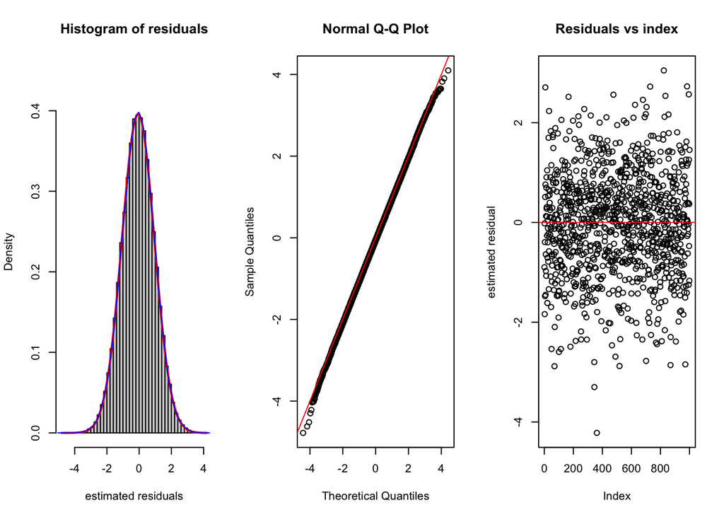

```r
par(mfrow=c(1,3))
hist(hat.e.2, prob=TRUE, breaks=40, ylim=c(0,0.45), main = 'Histogram of residuals', xlab = 'estimated residuals')
curve(dnorm(x, mean(hat.e.2), sd(hat.e.2)), add=TRUE, col="red", lwd=2)
lines(density(hat.e.2), col='blue')
qqnorm(hat.e.2)
abline(a=0, b=1, col='red')
s <- sample(1:length(hat.e.2), 1000)
plot(hat.e.2[s], ylab = 'estimated residual', main = "Residuals vs index"  )
abline(a=0, b=0, col='red')
```

## 3. Training NNs with a non-mixing data.

### 3.1. Generation of the data

For simplicity, we consider here $K=1$.

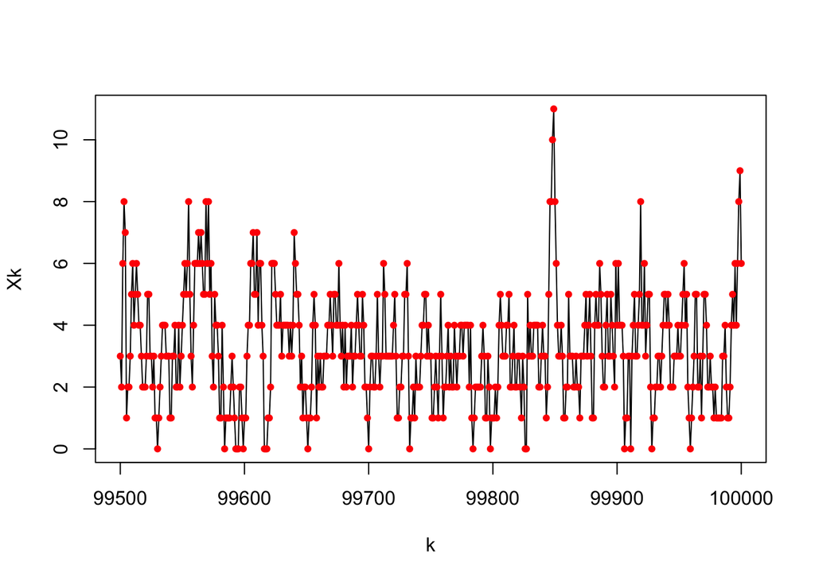

```r
n=100000
p=0.7
lmda =1
X <- c(NA)
X[1] <- rpois(1,lambda = lmda)
for (i in 1:n){
  X[i+1] <- sum(rbinom(X[i],1,p)) + rpois(1,lmda)
}
plot((n-500):n, X[(n-500):n], type = 'l', xlim = c((n-500),n), xlab = "k", ylab = "Xk")
points((n-500):n,X[(n-500):n], col='red', pch = 20 )
```

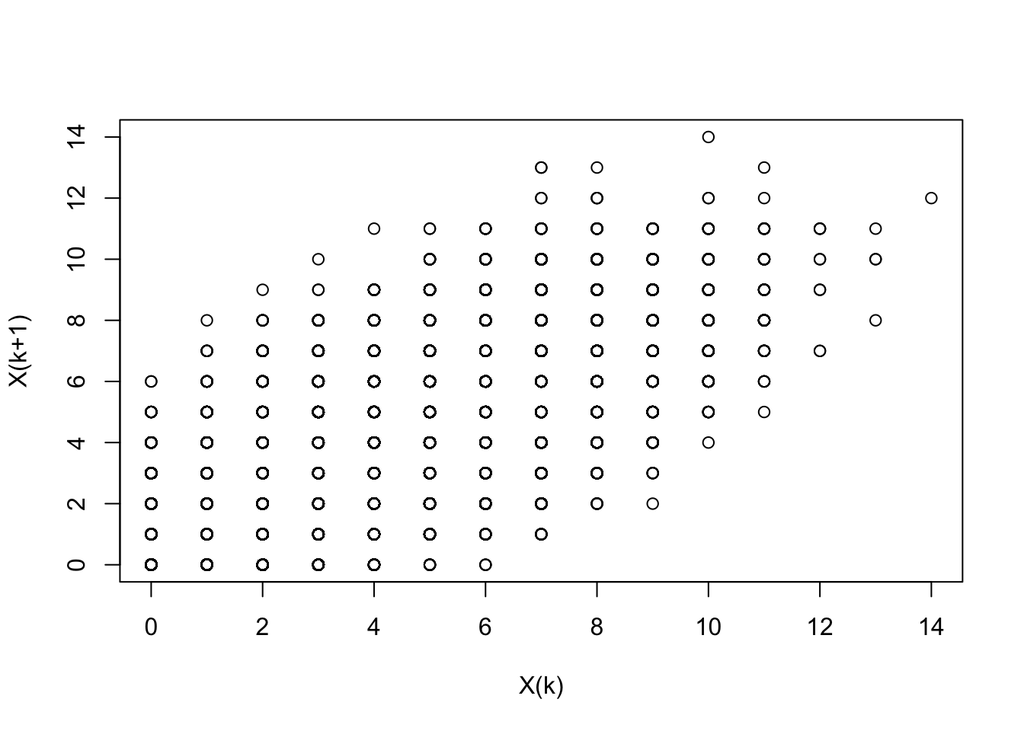

```r
Xt <- X[1:(n-1)]
Xt1 <- X[2:n]
plot(Xt,Xt1, xlab = "X(k)", ylab = "X(k+1)")
```

### 3.2. Estimation or learning

```r
model_nm <- keras_model_sequential()

  model_nm %>%
  layer_dense(units = 150, input_shape = 1) %>%
  #layer_dropout(rate=0.25)%>%
  layer_activation(activation = 'sigmoid') %>%
  layer_dense(units = 150) %>%
  layer_activation(activation = 'sigmoid') %>%
  layer_dense(units = 150) %>%
  layer_activation(activation = 'sigmoid') %>%
  layer_dense(units = 150) %>%
  layer_activation(activation = 'sigmoid') %>%
  layer_dense(units = 1)

model_nm %>% compile(
  loss = 'mean_squared_error',
  optimizer = optimizer_sgd(learning_rate = 0.001), #lr = 0.001, decay = 0.5,
  metrics = 'mae'
)

X.train_nm <- X[1:(n-1)]
Y.train_nm <- X[2:n]

model_nm %>% fit(X.train_nm,
               Y.train_nm,
               epochs=20
               )
cat("\014") # is the code to send CTRL+L to the console and therefore will clear the screen.
```

### 3.3. Study of the resilduals.

To do this, we first transform the list of weights and biases calculated in Keras format to our format in order to give the estimated autogression functions

```r
theta <- T_KG(get_weights(model_nm))
```

```
## [1] 10
```

and calculate the errors $\hat{\epsilon}_k=X_k-f(X_{t-1}; \hat{\theta})$ according to the case

```r
hat.e_nm <- Y.train_nm - apply(as.matrix(X.train_nm), 1, function(x){model_function(theta, sigmoid, x)})
```

The following figures shows the Gaussian behavior of the errors obtained

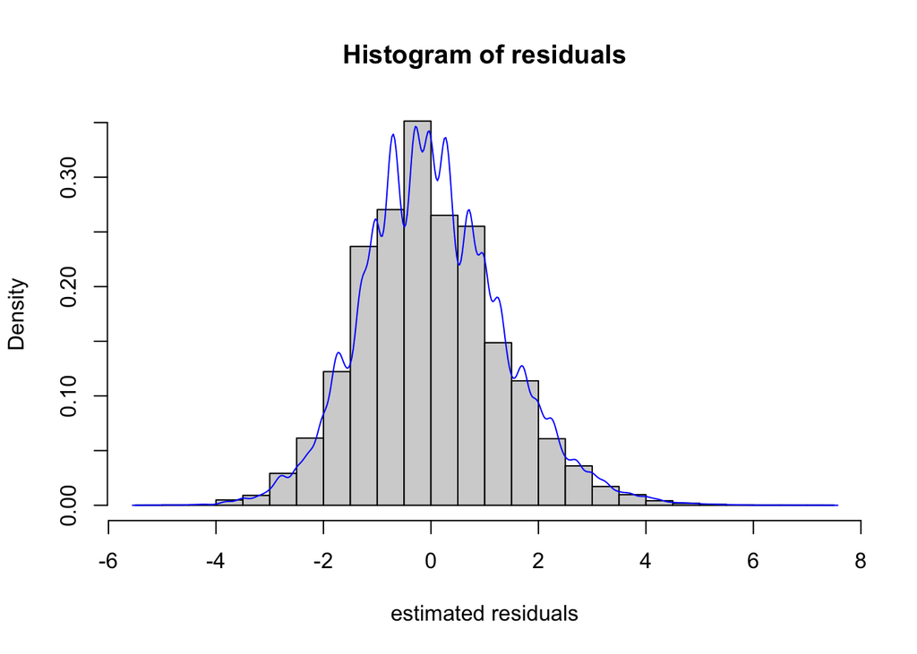

```r
hist(hat.e_nm, prob=TRUE, breaks=40, ylim=c(0,0.35), main = 'Histogram of residuals', xlab = 'estimated residuals')
lines(density(hat.e_nm), col='blue')
```

## 4. Link between the number of neurons and the variability of the estimated residuals

### 4.1. Learning of a non-linear based data

#### 4.1.1. Generation of the time series

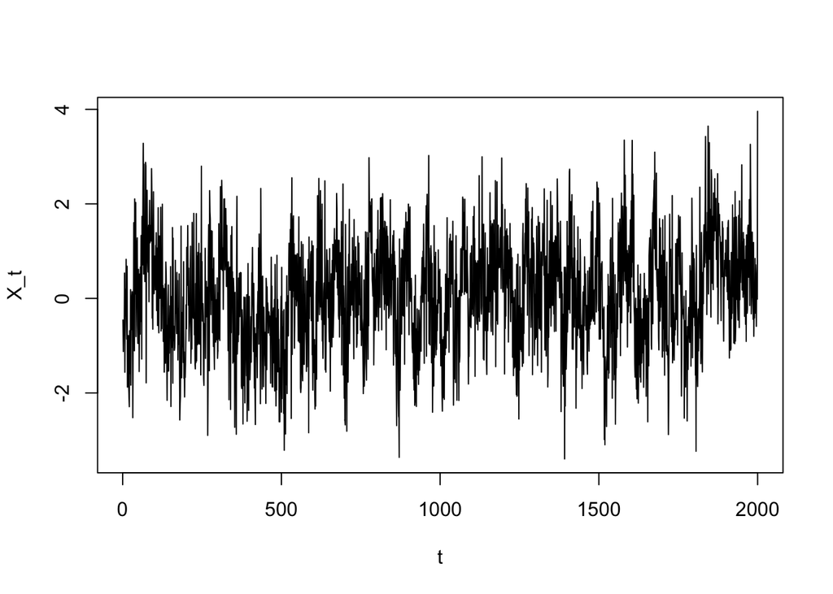

```r
n1 <- 100000
X_nl <- c(NA)
p1 <-  5
X_nl[1:p1] <- rnorm(p1)
e_a <- rnorm(n1+100)
parameter1 <- c(0.15, 0.2, 0.15, 0.1, 0.3)
c_a <- sum(parameter1)
for (t in ((p1+1):(n1+100))){
  X_nl[t] <- sin(parameter1%*%(X_nl[(t-1):(t-p1)])) + e_a[t]
}
Xt_nl <- X_nl[100:length(X_nl)]
plot(Xt_nl[1:2000], type='l', ylab = 'X_t', xlab = 't')
```

#### 4.1.2 Link between variability and number of neurons

```r
Variance1 <- c(NA)
Mean1 <- c(NA)
Mae1 <-c(NA)
epsilons1 <- list(NA)

Mn1 <- 10
Data1 <- matrix(NA, ncol = p1+1, nrow = n1-p1)
for (t in 1:(n1-p1)){
  Data1[t,] <- Xt_nl[(t+p1):t]
}
X.train_v1 <- Data1[, 2:ncol(Data1)]
Y.train_v1 <- Data1[,1]

for (k in 1:Mn1){
  nbr.neu = 30 + 30*(k-1)
  model_aux <- keras_model_sequential()

  model_aux %>%
  layer_dense(units = nbr.neu, input_shape = p1) %>%
  layer_activation(activation = 'relu') %>%
  layer_dense(units = nbr.neu) %>%
  layer_activation(activation = 'relu') %>%
  layer_dense(units = nbr.neu ) %>%
  layer_activation(activation = 'relu') %>%
  layer_dense(units = nbr.neu ) %>%
  layer_activation(activation = 'relu') %>%
  layer_dense(units = 1)

model_aux %>% compile(
  loss = 'mean_squared_error',
  optimizer = optimizer_sgd(learning_rate = 0.01),
  #metrics = 'mae'
)

model_aux %>% fit(X.train_v1, Y.train_v1, epochs = 50) #epochs=500 for the paper

cat("\014") # is the code to send CTRL+L to the console and therefore will clear the screen.
#-----
theta_aux <- T_KG(get_weights(model_aux))
hat.e_aux <- Y.train_v1 - apply(X.train_v1, 1, function(x){model_function(theta_aux, relu, x)})
Variance1[k] <- var(hat.e_aux)
Mean1[k] <- mean(hat.e_aux)
Mae1[k] <- mean(abs(hat.e_aux))
epsilons1[[k]] <- hat.e_aux
}
```

```
## [1] 10
## [1] 10
## [1] 10
## [1] 10
## [1] 10
## [1] 10
## [1] 10
## [1] 10
## [1] 10
## [1] 10
```

```r
cat("\014")
```

```r
sample_epsilons1 <- list(NA)
set <- sample(1:n1, 100)
for (k in 1:Mn1){
  sample_epsilons1[[k]] <- epsilons1[[k]][set]
}
```

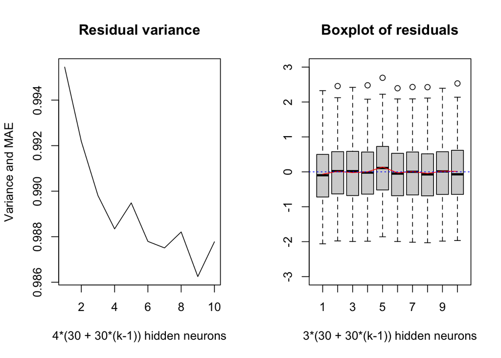

```r
par(mfrow=c(1,2))
plot(Variance1, type='l', xlab='4*(30 + 30*(k-1)) hidden neurons', main = 'Residual variance', ylab = "Variance and MAE", xlim=c(1,10))
lines(Mae1, col='red')
boxplot(sample_epsilons1, ylim=c(-3,3), xlim=c(0.5,10.5), xlab='3*(30 + 30*(k-1)) hidden neurons', main='Boxplot of residuals')
#boxplot(epsilons1, ylim=c(-5,5), xlim=c(0.5,10.5), xlab='3*(30 + 30*(k-1)) hidden neurons', main='Boxplot of residuals')
lines(Mean1, col='red')
abline(a=0, b=0, col='blue', lty=3)
```

### 4.2. Learning of AR-ARCH-based data (mixing data)

#### 4.2.2. Generation of the time series

Here, we work with $K=1$ regimes. Moreover, we consider a volatility function within resildual part. Precisely, we consider a AR-ARCH model.

```r
n2 <- 100000
X_arch <- c(NA)
p2 <- 5
X_arch[1:p2] <- rnorm(5)
e_a <- rnorm(n2+100)
parameter1 <- c(0.05, 0.05, 0.015, 0.1, 0.03)
parameter2 <- c(0.1, 0.1, 0.1, 0.25, 0.1)
c_a <- sum(parameter1) + sum(parameter2)
c_a
```

```
## [1] 0.895
```

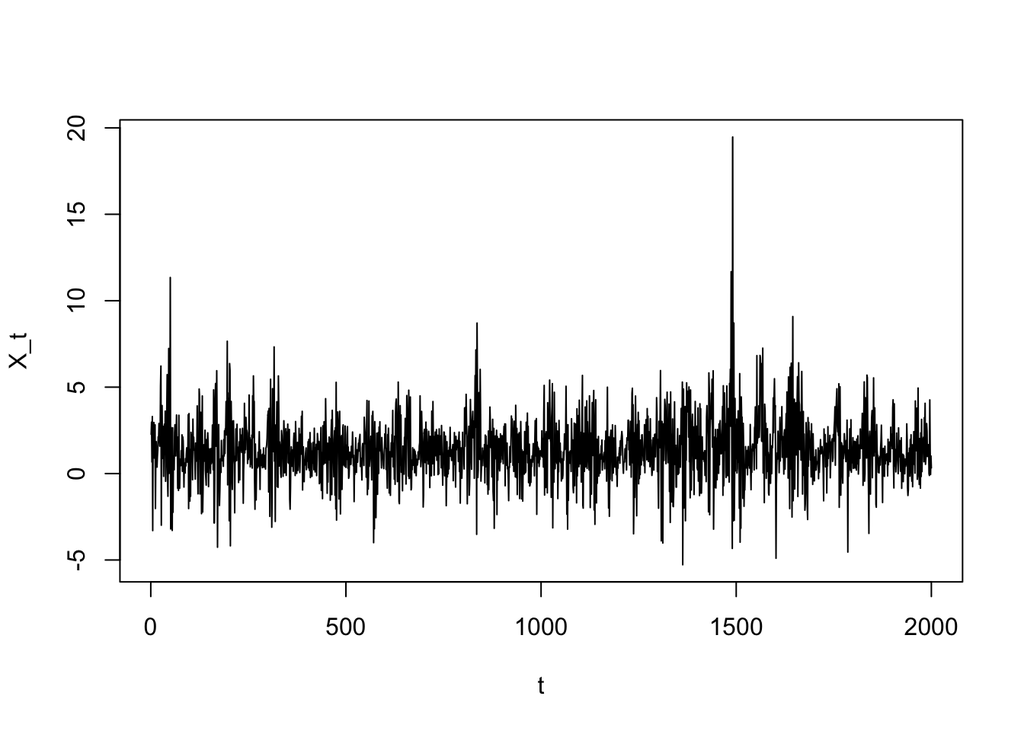

```r
for (t in ((p2+1):(n2+100))){
  X_arch[t] <- 1 + parameter1%*%(X_arch[(t-1):(t-p2)]) + sqrt(parameter2%*%(X_arch[(t-1):(t-p2)])^2)*e_a[t]
  # X_arch[t] <- 100*sin(pi*t/500) + parameter1%*%(X_arch[(t-1):(t-p)]) + sqrt(parameter2%*%(X_arch[(t-1):(t-p)])^2)*e_a[t]
}
Xt_arch <- X_arch[100:length(X_arch)]
plot(Xt_arch[1:2000], type='l', ylab = 'X_t', xlab = 't')
```

#### 4.2.3 Link between variability and number of neurons

```r
Variance2 <- c(NA)
Mean2 <- c(NA)
Mae2 <-c(NA)
epsilons2 <- list(NA)
#
Mn2 <- 10
Data2 <- matrix(NA, ncol = p2+1, nrow = n2-p2)
for (t in 1:(n2-p2)){
  Data2[t,] <- Xt_arch[(t+p2):t]
}
X.train_v2 <- Data2[, 2:ncol(Data2)]
Y.train_v2 <- Data2[,1]

for (k in 1:Mn2){
  nbr.neu = 30 + 30*(k-1)
  model_aux <- keras_model_sequential()

  model_aux %>%
  layer_dense(units = nbr.neu, input_shape = p2) %>%
  layer_activation(activation = 'relu') %>%
  layer_dense(units = nbr.neu) %>%
  layer_activation(activation = 'relu') %>%
  layer_dense(units = nbr.neu ) %>%
  layer_activation(activation = 'relu') %>%
  layer_dense(units = nbr.neu ) %>%
  layer_activation(activation = 'relu') %>%
  layer_dense(units = 1)

model_aux %>% compile(
  loss = 'mean_squared_error',
  optimizer = optimizer_sgd(learning_rate = 0.001),
  #metrics = 'mae'
)

model_aux %>% fit(X.train_v2, Y.train_v2, epochs = 50) #epochs = 500 for the paper

cat("\014") # is the code to send CTRL+L to the console and therefore will clear the screen.
#-----
theta_aux <- T_KG(get_weights(model_aux))
hat.e_aux <- Y.train_v2 - apply(X.train_v2, 1, function(x){model_function(theta_aux, relu, x)})
Variance2[k] <- var(hat.e_aux)
Mean2[k] <- mean(hat.e_aux)
Mae2[k] <- mean(abs(hat.e_aux))
epsilons2[[k]] <- hat.e_aux
}
```

```
## [1] 10
## [1] 10
## [1] 10
## [1] 10
## [1] 10
## [1] 10
## [1] 10
## [1] 10
## [1] 10
## [1] 10
```

```r
cat("\014")
```

```r
sample_epsilons2 <- list(NA)
set <- sample(1:n2, 100)
for (k in 1:Mn2){
  sample_epsilons2[[k]] <- epsilons2[[k]][set]
}
```

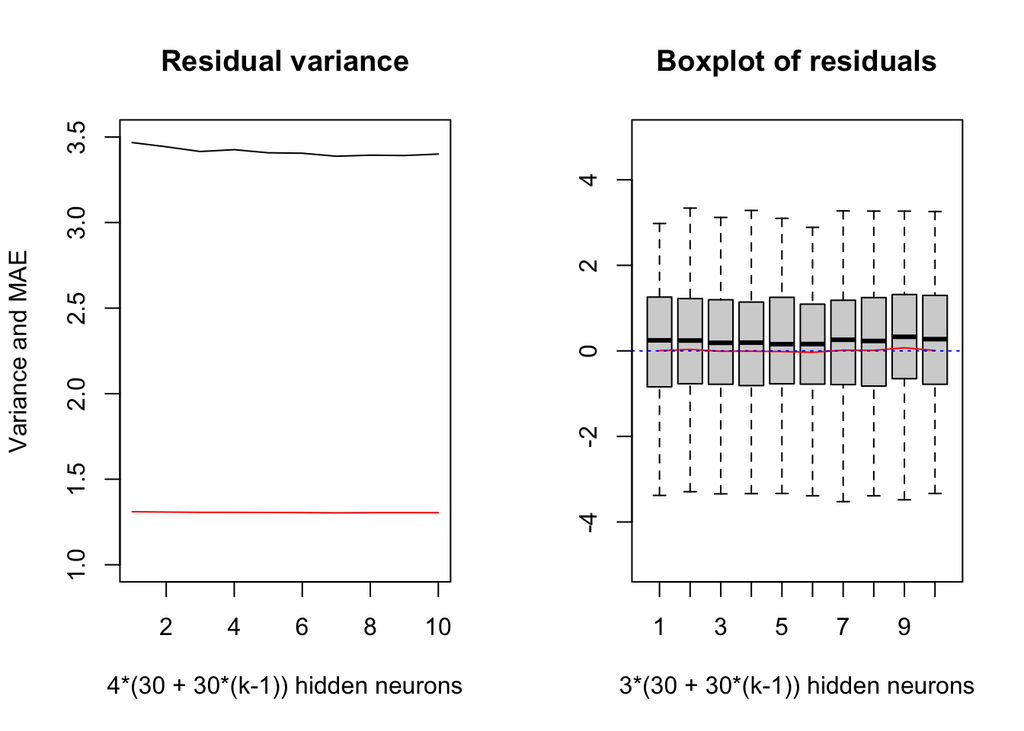

```r
par(mfrow=c(1,2))
plot(Variance2, ylim = c(1,3.5), type='l', xlab='4*(30 + 30*(k-1)) hidden neurons', main = 'Residual variance', ylab = "Variance and MAE", xlim=c(1,10))
lines(Mae2, col='red')
boxplot(sample_epsilons2, ylim=c(-5,5), xlim=c(0.5,10.5), xlab='3*(30 + 30*(k-1)) hidden neurons', main='Boxplot of residuals')
#boxplot(epsilons2, ylim=c(-10,10), xlim=c(0.5,10.5), xlab='3*(30 + 30*(k-1)) hidden neurons', main='Boxplot of residuals')
lines(Mean2, col='red')
abline(a=0, b=0, col='blue', lty=3)
```

## 5. Asymptotic normality of trained NNs.

### 5.1. Generation of the data

#### 5.1.1. Generation of the true parameter $\theta^{0}$ of the model:

```r
red1 <- sample.model.architecture(c(16,32,64,32,1), 0.08)
red2 <- sample.model.architecture(c(16,64,32,1), 0.035)
red3 <- sample.model.architecture(c(16,32,64, 1), 0.07)
```

```r
red1[[1]][[length(red1[[1]])]][1,21] <- 1
red2[[1]][[length(red2[[1]])]][1,6] <- 0
red3[[1]][[length(red3[[1]])]][1,31] <- -1
```

We set the probabilities $(\pi_1, \pi_2, \pi_3)=(0.4, 0.5, 0.1)$. Notice that $c=\sum_{k=1}^{3}\pi_k A_k$ must be less than or equal to 1 in order to obtain the stationarity of the model. In fact,

```r
prob <- c(0.4, 0.5, 0.1)
c <- prob%*%c(red1[[2]], red2[[2]], red3[[2]])
c
```

```
##           [,1]
## [1,] 0.9541972
```

Once we have verified that $c <1$, we forget the $A_k=redk[[2]]$ and we rename the parameters as follows:

```r
red1 <- red1[[1]]
red2 <- red2[[1]]
red3 <- red3[[1]]

red1_0 <- unlist(red1)
red2_0 <- unlist(red2)
red3_0 <- unlist(red3)
n.parameters <- length(c(red1_0, red2_0, red3_0))
```

### 5.2. Monte Carlo simulation

```r
n.samplings <- 125
n <- 50000
n.iterations.bp <- 100 #This is the number of iteration of the SGD algorithm.
p <- ncol(red1[[1]])-1
theta.centered <- matrix(NA, ncol = n.parameters, nrow = n.samplings)
for (i in 1:n.samplings){
  print(paste("Iteration = ", i))
  X <- c(NA)
  e <- rnorm(n+100)
  X[1:p] <- e[1:p]
  S <- Switching(n+100,prob)
  for (t in (p+1):(n+100)){
    X[t] <- (rep(S[t],length(prob)) == 1:length(prob))%*%c(model_function(red1, sigmoid, X[(t-1):(t-p)]),
                                                             model_function(red2, sigmoid, X[(t-1):(t-p)]),
                                                             model_function(red3, sigmoid, X[(t-1):(t-p)]))+e[t]
  }
  St <- S[101:length(S)]
  Xt <- X[101:length(S)]
  # Estimation
  D <- matrix(NA, ncol = p+2, nrow = n-p)
  for (t in 1:(n-p)){
    D[t,] <- c(St[t+p], Xt[(t+p):t])
  }
  #---
  D1 <- D[Index_Switching(D[,1],1),]

  model1 <- keras_model_sequential()

  model1 %>%
    layer_dense(units = 32, input_shape = 16) %>%
    layer_activation(activation = 'sigmoid') %>%
    layer_dense(units = 64) %>%
    layer_activation(activation = 'sigmoid') %>%
    layer_dense(units = 32) %>%
    layer_activation(activation = 'sigmoid') %>%
    layer_dense(units = 1)

  model1 %>% compile(
    loss = 'mean_squared_error',
    optimizer = optimizer_sgd(learning_rate = 0.001,  decay = 0.2)
    #metrics = 'mae'
  )

  X.train1 <- D1[, 3:ncol(D1)]
  Y.train1 <- D1[,2]

  model1 %>% fit(X.train1, Y.train1, epochs = n.iterations.bp)
  cat("\014") # is the code to send CTRL+L to the console and therefore will clear the screen.

  theta1.centered <- (unlist(T_KG(get_weights(model1))) - red1_0)*sqrt(n-p)
  #-----------------------------------
  D2 <- D[Index_Switching(D[,1],2),]

  model2 <- keras_model_sequential()

  model2 %>%
    layer_dense(units = 64, input_shape = 16) %>%
    layer_activation(activation = 'sigmoid') %>%
    layer_dense(units = 32) %>%
    layer_activation(activation = 'sigmoid') %>%
    layer_dense(units = 1)

  model2 %>% compile(
    loss = 'mean_squared_error',
    optimizer = optimizer_sgd(learning_rate = 0.001) #, decay = 0.5
    #metrics = 'mae'
  )

  X.train2 <- D2[, 3:ncol(D2)]
  Y.train2 <- D2[,2]

  model2 %>% fit(X.train2, Y.train2, epochs = n.iterations.bp)
  cat("\014") # is the code to send CTRL+L to the console and therefore will clear the screen.

  theta2.centered <- (unlist(T_KG(get_weights(model2))) - red2_0)*sqrt(n-p)
  #--------------------------------
  D3 <- D[Index_Switching(D[,1],3),]

  model3 <- keras_model_sequential()

  model3 %>%
    layer_dense(units = 32, input_shape = 16) %>%
    layer_activation(activation = 'sigmoid') %>%
    layer_dense(units = 64) %>%
    layer_activation(activation = 'sigmoid') %>%
    layer_dense(units = 1)

  model3 %>% compile(
    loss = 'mean_squared_error',
    optimizer = optimizer_sgd(learning_rate = 0.001,  decay = 0.2) #, decay = 0.5
    #metrics = 'mae'
  )

  X.train3 <- D3[, 3:ncol(D3)]
  Y.train3 <- D3[,2]

  model3 %>% fit(X.train3, Y.train3, epochs = n.iterations.bp)
  cat("\014") # is the code to send CTRL+L to the console and therefore will clear the screen.

  theta3.centered <- (unlist(T_KG(get_weights(model3))) - red3_0)*sqrt(n-p)

#-----------------------------------------------------------------------------------
  theta.centered[i, ] <- c(theta1.centered, theta2.centered, theta3.centered)
}
```

```
## [1] "Iteration =  1"
## [1] 8
## [1] 6
## [1] 6
## [1] "Iteration =  2"
## [1] 8
## [1] 6
## [1] 6
## [1] "Iteration =  3"
## [1] 8
## [1] 6
## [1] 6
## [1] "Iteration =  4"
## [1] 8
## [1] 6
```

[output cut: 485 more lines]

### 5.3. Multivariate Test Normality

Finally we apply several tests in order to study the normality of the estimator.

#### 5.3.1. The boxplots of a subset of $100$ parameters.

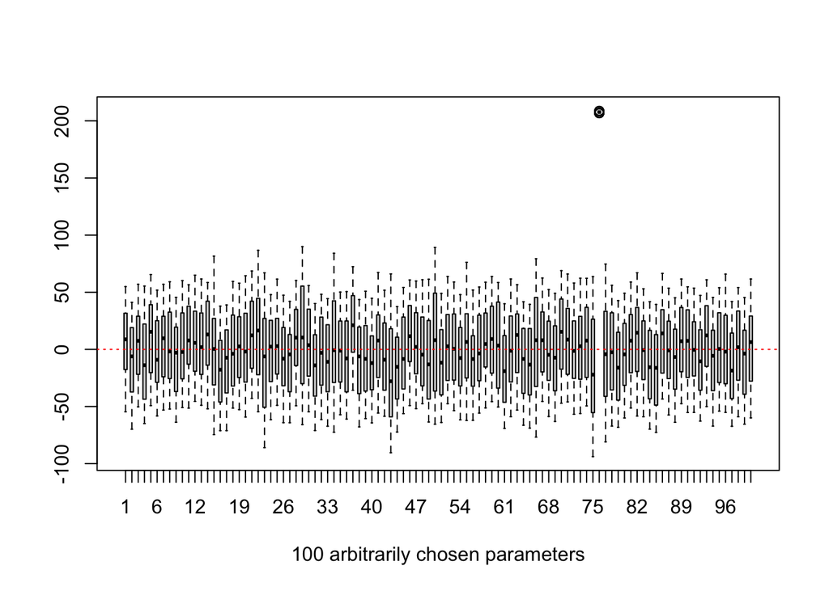

```r
set <- sample(1:ncol(theta.centered), 100)
boxplot(theta.centered[, set], boxwex=0.5, xlab='100 arbitrarily chosen parameters')
abline(h=0,lty=9, col='red')
```

```r
set2 <- sample(1:ncol(theta.centered), 15)
```

If package `MVN` is not disponible, use `charme_tools_MVN.R`.

```r
source("charme_tools_MVN.R")
```

Mardia’s Test:

```r
result1 <- mardiaTest(theta.centered[, set2],qqplot=FALSE)
result1
```

```
##    Mardia's Multivariate Normality Test
## ---------------------------------------
##    data : theta.centered[, set2]
##
##    g1p            : 28.00868
##    chi.skew       : 583.5142
##    p.value.skew   : 0.9968635
##
##    g2p            : 240.415
##    z.kurtosis     : -3.610314
##    p.value.kurt   : 0.0003058269
##
##    chi.small.skew : 599.3022
##    p.value.small  : 0.988184
##
##    Result          : Data are not multivariate normal.
## ---------------------------------------
```

Royston’s Test:

```r
#library(moments)
#result2 <- roystonTest(theta.centered[, set2], qqplot = FALSE )
#result2
```

Henze-Zirkler’s Test:

```r
#result3 <- hzTest(theta.centered[, set2], qqplot= TRUE)
#result3
```